# Reading the QuakeScope pick catalogue

Machine-learning phase picks for the western United States, as Parquet on S3. **No credentials, no database, no account.** The catalogue is public-read and every cell below runs anonymously, on Colab or a laptop, in about five minutes.

This notebook:

1. installs what it needs,
2. looks at the station table,
3. mirrors one month of one network and reads it,
4. plots what is in it,
5. fetches the **original waveforms** from FDSN with ObsPy and draws the picks on top,
6. reads the run record that says which model produced them,
7. shows how to read at scale without waiting an afternoon.

| bucket | `s3://quakescope-picks-2026`, us-east-2, public-read |
| --- | --- |
| catalogue used here | `western`: PhaseNet `original`, 1986 to 2026, 26,377 station-locations, 1.81 billion picks on 2026-10-08 (growing: a re-read of station-days a reader defect skipped runs from 2026-10-08) |
| layout | `<campaign>/picks/network=<NET>/year=<YYYY>/month=<MM>/*.parquet` |
| provenance | `<campaign>/runs/<rid>.json` |
| reference | [`docs/data_access.md`](https://github.com/SeisSCOPED/QuakeScope/blob/main/docs/data_access.md) |

For a region, a period, coverage checks and bulk export, continue with `download_the_catalogue.ipynb`.

## 1. Install

Safe to re-run; skip it if you already have these.

```python
# Colab already has pandas/numpy/matplotlib. These are the rest; installed only if missing.
import importlib.util
missing = [m for m in ("pyarrow", "s3fs", "obspy", "duckdb") if importlib.util.find_spec(m) is None]
if missing:
    %pip install -q {" ".join(missing)}
print("ready" + (f" (installed {', '.join(missing)})" if missing else ""))
```

```
ready
```

```python
import time
from pathlib import Path

import numpy as np
import pandas as pd
import matplotlib.pyplot as plt
import s3fs

BUCKET = "quakescope-picks-2026"
CAMPAIGN = "western"
ANON = {"anon": True}              # public-read: no keys, no config, no account
fs = s3fs.S3FileSystem(anon=True)

MIRROR = Path("quakescope_mirror")  # where partitions land when we copy them down
MIRROR.mkdir(exist_ok=True)

C_P, C_S = "#2a78d6", "#eb6834"
```

## 2. The station table

`stations.parquet` is the table the campaign was planned from: every station-location with its coordinates, the bands the archive lists for it, its operating window and (for the western campaign) the state it sits in. It is the index for choosing what to read.

```python
stations = pd.read_parquet(f"s3://{BUCKET}/{CAMPAIGN}/stations.parquet", storage_options=ANON)
# Networks from `id`: the code columns of tables written before the 2026-10
# fix carry CSV-parse damage ("0.0" for location "00"); `id` never did.
print(f"{len(stations):,} station-locations, {stations.id.str.split('.').str[0].nunique()} networks")
print(stations.state.value_counts(dropna=False).to_string(), "\n")
stations.head()
```

```
26,377 station-locations, 154 networks
state
California                  10537
Washington                   7740
Wyoming                      2812
Nevada                       1445
Oregon                       1299
Utah                         1009
Montana                       365
British Columbia (Ca)         291
Idaho                         251
Arizona                       245
Colorado                      117
Alberta (Ca)                   68
Baja California (Me)           61
None                           60
New Mexico                     35
Baja California Sur (Me)       20
Sonora (Me)                    19
Saskatchewan (Ca)               3
```

|  | id | network_code | station_code | location_code | channels | latitude | longitude | elevation | start_date | end_date | state | start_yearday | end_yearday |
| --- | --- | --- | --- | --- | --- | --- | --- | --- | --- | --- | --- | --- | --- |
| 0 | 1A.BOC1. | 1A | BOC1 |  | EH | 35.2562 | -111.6232 | 2256.0 | 2019-08-15 | 2019-11-22 | Arizona | 2019.227 | 2019.326 |
| 1 | 1A.BOC2. | 1A | BOC2 |  | EH,SH | 35.2561 | -111.6236 | 2347.0 | 2020-06-16 | 2020-11-11 | Arizona | 2020.168 | 2020.316 |
| 2 | 1A.C18A. | 1A | C18A |  | EH | 35.2582 | -111.6080 | 2608.0 | 2019-08-13 | 2019-11-25 | Arizona | 2019.225 | 2019.329 |
| 3 | 1A.C19A. | 1A | C19A |  | EH | 35.2563 | -111.6087 | 2621.0 | 2019-08-13 | 2019-10-10 | Arizona | 2019.225 | 2019.283 |
| 4 | 1A.C19B. | 1A | C19B |  | EH | 35.2557 | -111.6084 | 2637.0 | 2019-08-13 | 2019-11-23 | Arizona | 2019.225 | 2019.327 |

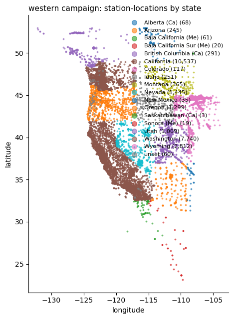

```python
fig, ax = plt.subplots(figsize=(7.5, 6.5))
for state, g in stations.groupby(stations.state.fillna("unset")):
    ax.scatter(g.longitude, g.latitude, s=3, alpha=0.6, label=f"{state} ({len(g):,})")
ax.set_xlabel("longitude"); ax.set_ylabel("latitude"); ax.set_aspect(1 / np.cos(np.radians(40)))
ax.legend(fontsize=8, markerscale=4, frameon=False)
ax.set_title("western campaign: station-locations by state", loc="left", fontsize=11)
ax.spines[["top", "right"]].set_visible(False)
fig.tight_layout()
```

## 3. Read some picks

```python
NET, YEAR, MONTH = "CI", 2019, 7
part = f"picks/network={NET}/year={YEAR}/month={MONTH:02d}/"

t0 = time.time()
fs.get(f"{BUCKET}/{CAMPAIGN}/{part}", str(MIRROR / CAMPAIGN / part), recursive=True)
n_files = sum(1 for _ in (MIRROR / CAMPAIGN / part).glob("*.parquet"))
print(f"mirrored {n_files} files in {time.time() - t0:.1f} s")

t0 = time.time()
picks = pd.read_parquet(MIRROR / CAMPAIGN / "picks")   # partition keys become columns
print(f"read {len(picks):,} picks in {time.time() - t0:.1f} s")
picks.head()
```

```
mirrored 275 files in 17.3 s
```

```
read 5,530,052 picks in 0.6 s
```

|  | tid | cha | pha | start | peak | end | conf | amp | amp_vel | rid | network | year | month |
| --- | --- | --- | --- | --- | --- | --- | --- | --- | --- | --- | --- | --- | --- |
| 0 | CI.SGL. | HH | P | 2019-07-05 00:13:18.198 | 2019-07-05 00:13:18.358 | 2019-07-05 00:13:18.588 | 0.545521 | 0.000045 | 6.442633e-07 | d345adb7-865c-40a6-9c93-894f94952b2c | CI | 2019 | 7 |
| 1 | CI.SGL. | HH | S | 2019-07-05 00:13:19.828 | 2019-07-05 00:13:19.998 | 2019-07-05 00:13:20.228 | 0.824467 | 0.000045 | 6.442633e-07 | d345adb7-865c-40a6-9c93-894f94952b2c | CI | 2019 | 7 |
| 2 | CI.SGL. | HH | P | 2019-07-05 00:18:55.038 | 2019-07-05 00:18:55.258 | 2019-07-05 00:18:55.428 | 0.470023 | NaN | 4.306997e-07 | d345adb7-865c-40a6-9c93-894f94952b2c | CI | 2019 | 7 |
| 3 | CI.SGL. | HH | P | 2019-07-05 00:19:05.888 | 2019-07-05 00:19:06.028 | 2019-07-05 00:19:06.268 | 0.328247 | NaN | 2.477334e-06 | d345adb7-865c-40a6-9c93-894f94952b2c | CI | 2019 | 7 |
| 4 | CI.SGL. | HH | P | 2019-07-05 00:33:08.228 | 2019-07-05 00:33:08.388 | 2019-07-05 00:33:08.858 | 0.361804 | NaN | 3.270497e-06 | d345adb7-865c-40a6-9c93-894f94952b2c | CI | 2019 | 7 |

Equivalent from a shell, if you have the AWS CLI:

```
aws s3 sync --no-sign-request s3://quakescope-picks-2026/western/picks/network=CI/year=2019/month=07/ \
    quakescope_mirror/western/picks/network=CI/year=2019/month=07/
```

### What the columns mean

| column | meaning |
| --- | --- |
| `tid` | trace id, `NET.STA.LOC`; the location code may be empty (`CI.CLC.`) |
| `cha` | band + instrument code the station-day was picked on (`HH`, `EH`, `BH`, `HN`, ...), one per station-day: the best band present that day (since image d0ccf9b, 2026-10-06) |
| `pha` | `P` or `S` |
| `start`, `peak`, `end` | the probability window; **`peak` is the arrival time**, millisecond resolution |
| `conf` | model confidence, 0 to 1. Everything at or above 0.2 is stored |
| `amp` | Wood-Anderson displacement, metres, for local magnitude. **Only measured for `conf` >= 0.5**, NaN otherwise |
| `amp_vel` | peak ground velocity near the pick, **m/s**: counts divided by each channel's instrument sensitivity and high-passed, max over components. Set on about 99 % of picks |
| `rid` | run id, resolves to `runs/<rid>.json` for the model and thresholds |
| `network`, `year`, `month` | the partition keys, read from the path |

`conf` is a **detection score, not a probability of correctness**. The stored floor of 0.2 is deliberately permissive so you can choose your own threshold; most analyses want considerably more than that.

```python
print(picks["pha"].value_counts().to_string(), "\n")
print(picks["conf"].describe().round(3).to_string(), "\n")
print(f"stations      : {picks['tid'].nunique():,}")
print(f"bands         : {picks['cha'].value_counts().to_dict()}")
print(f"amp measured  : {picks['amp'].notna().mean():.1%} of picks, "
      f"{picks.loc[picks.conf >= 0.5, 'amp'].notna().mean():.1%} of those with conf >= 0.5")
print(f"amp_vel set   : {picks['amp_vel'].notna().mean():.1%}")
```

```
pha
S    2882944
P    2647108
```

```
count    5530052.000
mean           0.530
std            0.253
min            0.200
25%            0.298
50%            0.471
75%            0.761
max            0.991
```

```
stations      : 306
```

```
bands         : {'HH': 5406290, 'HN': 89830, 'EH': 33932}
amp measured  : 46.4% of picks, 99.1% of those with conf >= 0.5
amp_vel set   : 99.3%
```

## 4. What the month looks like

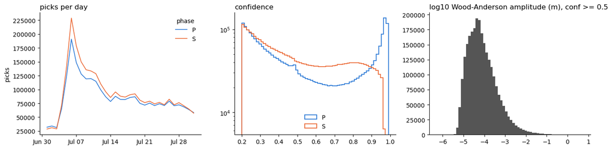

```python
import matplotlib.dates as mdates

fig, ax = plt.subplots(1, 3, figsize=(14, 3.6))

daily = picks.groupby([picks["peak"].dt.floor("D"), "pha"]).size().unstack(fill_value=0)
for ph, c in (("P", C_P), ("S", C_S)):
    ax[0].plot(daily.index, daily[ph], lw=1.2, color=c, label=ph)
ax[0].legend(title="phase", frameon=False)
ax[0].set_title("picks per day", loc="left"); ax[0].set_ylabel("picks")
ax[0].xaxis.set_major_formatter(mdates.DateFormatter("%b %d"))
ax[0].xaxis.set_major_locator(mdates.DayLocator(interval=7))

for ph, c in (("P", C_P), ("S", C_S)):
    ax[1].hist(picks.loc[picks.pha == ph, "conf"], bins=60, histtype="step", lw=1.3, color=c, label=ph)
ax[1].set_yscale("log"); ax[1].set_title("confidence", loc="left"); ax[1].legend(frameon=False)

amp = picks["amp"].dropna()
amp = amp[amp > 0]
ax[2].hist(np.log10(amp), bins=60, color="#555")
ax[2].set_title("log10 Wood-Anderson amplitude (m), conf >= 0.5", loc="left")

for a in ax:
    a.spines[["top", "right"]].set_visible(False)
fig.tight_layout()
```

The daily curve is the useful sanity check: **P and S should track each other**, and a day where one collapses is usually a data outage rather than a quiet Earth. The step on July 4 and 6 is the Ridgecrest foreshock and mainshock.

## 5. Fetch the waveforms and check the picks

Picks are only as good as they look on the record. The catalogue stores no waveforms, so fetch them from the **SCEDC FDSN service** with ObsPy: the same data the picker read, from the archive of record.

```python
import obspy
from obspy.clients.fdsn import Client

day = picks[(picks.conf >= 0.5) & (picks.peak.dt.floor("D") == pd.Timestamp("2019-07-06"))].copy()
day["minute"] = day["peak"].dt.floor("min")
tid, minute = day.groupby(["tid", "minute"]).size().idxmax()
net, sta, loc = tid.split(".")
band = picks.loc[picks.tid == tid, "cha"].iloc[0]
print(f"{tid}  {minute}  band {band}")

t0 = obspy.UTCDateTime(minute) - 10
st = Client("SCEDC", timeout=60).get_waveforms(
    network=net, station=sta, location=loc or "--", channel=f"{band}?",
    starttime=t0, endtime=t0 + 80,
)
st.merge(fill_value="interpolate").detrend("demean").filter("bandpass", freqmin=2, freqmax=20)
print(st)
```

```
CI.CCC.  2019-07-06 16:43:00  band HH
```

```
3 Trace(s) in Stream:
CI.CCC..HHE | 2019-07-06T16:42:49.998300Z - 2019-07-06T16:44:09.998300Z | 100.0 Hz, 8001 samples
CI.CCC..HHN | 2019-07-06T16:42:49.998300Z - 2019-07-06T16:44:09.998300Z | 100.0 Hz, 8001 samples
CI.CCC..HHZ | 2019-07-06T16:42:49.998300Z - 2019-07-06T16:44:09.998300Z | 100.0 Hz, 8001 samples
```

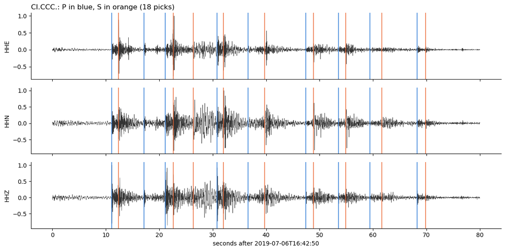

```python
window = picks[(picks.tid == tid) &
               (picks.peak >= minute - pd.Timedelta(seconds=10)) &
               (picks.peak < minute + pd.Timedelta(seconds=70))]

fig, axes = plt.subplots(len(st), 1, figsize=(12, 6), sharex=True)
for ax, tr in zip(np.atleast_1d(axes), st):
    t = tr.times() + (tr.stats.starttime - t0)
    ax.plot(t, tr.data / np.abs(tr.data).max(), lw=0.45, color="#333")
    for _, p in window.iterrows():
        ax.axvline(obspy.UTCDateTime(p["peak"]) - t0, lw=1.3, alpha=0.85,
                   color=C_P if p["pha"] == "P" else C_S)
    ax.set_ylabel(tr.stats.channel)
    ax.spines[["top", "right"]].set_visible(False)
axes[-1].set_xlabel(f"seconds after {t0.isoformat()}")
axes[0].set_title(f"{tid}: P in blue, S in orange ({len(window)} picks)", loc="left")
fig.tight_layout()
```

Zoom in on a single pick to judge it properly. Change `i` to step through them; low-`conf` picks are where the interesting disagreements live.

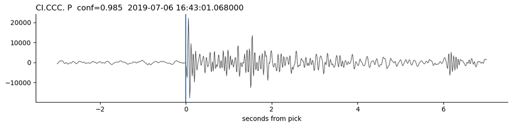

```python
i = 0
p = window.sort_values("peak").iloc[i]
tp = obspy.UTCDateTime(p["peak"])
tr = st.select(component="Z")[0].slice(tp - 3, tp + 7)

plt.figure(figsize=(11, 2.8))
plt.plot(tr.times() - 3, tr.data, lw=0.7, color="#333")
plt.axvline(0, color=C_P if p["pha"] == "P" else C_S, lw=1.5)
plt.title(f"{tid} {p['pha']}  conf={p['conf']:.3f}  {p['peak']}", loc="left")
plt.xlabel("seconds from pick"); plt.gca().spines[["top", "right"]].set_visible(False)
plt.tight_layout()
```

## 6. Provenance

Every pick carries a run id. The run record says exactly which model, weights, thresholds and library version produced it. A campaign runs under one configuration, but every worker start creates a new run id, so there are thousands of records that differ only in `run_id` and `created`: quote the configuration, not the id.

```python
import json, urllib.request

rid = picks["rid"].iloc[0]
url = f"https://{BUCKET}.s3.us-east-2.amazonaws.com/{CAMPAIGN}/runs/{rid}.json"
run = json.load(urllib.request.urlopen(url))
print(json.dumps(run, indent=2))

# and the whole month ran under one configuration:
print(f"\n{picks.rid.nunique()} run ids in this month")
```

```
{
  "run_id": "d345adb7-865c-40a6-9c93-894f94952b2c",
  "created": "2026-09-04T01:40:26.051924+00:00",
  "model": "PhaseNet",
  "weight": "original",
  "p_threshold": "0.2",
  "s_threshold": "0.2",
  "components_loaded": "ZNE12",
  "seisbench_version": "0.12.5",
  "weight_version": "2"
}
```

```
62 run ids in this month
```

## 7. Reading it at scale

One month of one network is 5.5 M picks and reads in under a second once mirrored. **The catalogue will not.** `western` is 1.81 billion picks in 490,018 Parquet objects (46.8 GB) on 2026-10-08, and growing while the re-read runs. At that size the thing that hurts is not bytes, it is **files**: reading a Parquet dataset means opening every file's footer, and that cost is paid per object however small your query.

Measured on 2026-09-16, anonymous, from a laptop:

| operation | objects touched | time |
| --- | --- | --- |
| mirror one month partition (271 files, 149 MB) | 271 | 9 to 12 s |
| read the mirrored month with pandas | 271 | 0.8 s |
| read the same month straight from S3 with `pandas` + `filters=` | 271 | 86 s |
| DuckDB `count(*)`, partition **in the path** | 271 | 7 s |
| DuckDB `count(*)`, `picks/**/*.parquet` with `WHERE network= AND year= AND month=` | 276,829 (490,018 on 2026-10-08) | **not back after 7 min** |

**Three rules, in the order they matter.**

### 1. Put the partition in the path

`network`, `year` and `month` come from the *path*. A glob over `picks/**` lists every object in the catalogue before any `WHERE` clause can prune it. Naming the partition in the path lists 271 objects instead of 490,000.

```python
import duckdb

con = duckdb.connect()
con.sql("INSTALL httpfs; LOAD httpfs; SET s3_region='us-east-2';")
con.sql("SET s3_access_key_id=''; SET s3_secret_access_key='';")   # anonymous

PART = f"s3://{BUCKET}/{CAMPAIGN}/picks/network={NET}/year={YEAR}/month={MONTH:02d}/*.parquet"

t0 = time.time()
n = con.sql(f"SELECT count(*) FROM read_parquet('{PART}', hive_partitioning=1)").fetchone()[0]
print(f"{n:,} picks in {time.time() - t0:.1f} s, straight from S3, partition in the path")
```

```
5,530,052 picks in 9.0 s, straight from S3, partition in the path
```

### 2. For anything bigger than a month, mirror first

```python
t0 = time.time()
busiest = con.sql(f'''
    SELECT tid,
           count(*)                        AS picks,
           count(*) FILTER (pha = 'S')     AS s_picks,
           round(avg(conf), 3)             AS mean_conf
    FROM read_parquet('{MIRROR / CAMPAIGN}/picks/**/*.parquet', hive_partitioning=1)
    GROUP BY tid
    ORDER BY picks DESC
    LIMIT 10
''').df()
print(f"{time.time() - t0:.2f} s against the local mirror")
busiest
```

```
0.07 s against the local mirror
```

|  | tid | picks | s_picks | mean_conf |
| --- | --- | --- | --- | --- |
| 0 | CI.WMF. | 243137 | 123669 | 0.673 |
| 1 | CI.WRC2. | 225225 | 115686 | 0.666 |
| 2 | CI.CLC. | 224689 | 113076 | 0.718 |
| 3 | CI.JRC2. | 204043 | 104194 | 0.699 |
| 4 | CI.MPM. | 188881 | 97789 | 0.699 |
| 5 | CI.TOW2. | 180075 | 90572 | 0.658 |
| 6 | CI.SRT. | 138907 | 66672 | 0.675 |
| 7 | CI.CCC. | 120306 | 60693 | 0.666 |
| 8 | CI.WHF. | 112802 | 60510 | 0.660 |
| 9 | CI.WBM. | 85723 | 45836 | 0.687 |

### 3. Aggregate in the engine, select only the columns you need

`.df()` materialises everything into memory. A count, a histogram or a per-station summary should come back already reduced. Parquet is columnar, so leaving `amp` and `amp_vel` out of a query that wants arrival times halves the bytes read; `SELECT *` reads them whether you use them or not.

### And the one that is not yours to fix: file size

A shard writes its own Parquet objects, so a partition accumulates hundreds of files of about 120 KB. Compaction into ~1 MB files is planned and will change object names, not content. Until then the rules above are what make the catalogue fast.

## 8. Going further

**A region and a period, not a network-month.** The download notebook selects stations from the station table, mirrors the matching partitions, checks which station-days were actually processed, and exports for an associator.

**Other catalogues.** `obs` is the ocean-bottom stations on the `obs` (PickBlue) weight, 1993 to 2026, offshore stations only since 2026-10-03 (land stations' picks moved to a non-public archive); `global` is every network EarthScope serves on `jma_wc`, paused at a few percent. Both share this layout and schema. Progress: the [campaign dashboard](https://seisscoped.org/QuakeScope/campaign_dashboard.html).

**Choosing a threshold.** Everything above `conf` 0.2 is stored, which is far more permissive than most uses want. Raise it and check the effect on your own target events rather than adopting a number from elsewhere; the benchmark reports show that the same threshold means different things for different weight sets.

**Associating into events.** These are per-station picks, not locations. A phase associator (PyOcto, GaMMA) turns them into events.

Catalogue and code: SeisSCOPED/QuakeScope. Reference for the layout, the access rules and the known limits: [`docs/data_access.md`](https://github.com/SeisSCOPED/QuakeScope/blob/main/docs/data_access.md).